# Corrélations fonctionelles - MB-PLS

## 1.2 AMR EHPAD FQ

Avec la régression PLS il n’est pas possible d’avoir un block X d’une seule variable donc on décide de ne pas traiter les blocks socio-eco et demo.

Pour le clustering de variable avec la fonction `CLV` du package `ClustVarLV`, il nous faut déterminer un critère car le nombre de variable par block est très hétérogène et cela est renforcé en plus par la séléction de variables préalable faite avec les GEEs.

- Quand il n’y a que 2 variable dans un block, on ne fait pas le clustering.
- Quand il y en a entre 3 et 5, on fait un clustering avec $K=2$ cluster.
- Quand il y a plus de 5 variables, on applique le critère du coude “inversé” sur le delta comme dans la publication *ClustVarLV: An R Package for the Clustering of Variables Around Latent Variables* (Vigneau et al., 2025). C’est à dire qu’on garde le nombre de cluster K à partir duquel le delta entre K et K+1 augmente de manière maximale.

```r
y <- "AMR_EHPAD_FQ_R"
time_period <- 2018:2022
var <- selvar_AMR_EHPAD_FQ
Nb.Base <- 5

automatisation_block <- function(y, blocks, time_period, var, Nb.Base){
# dataset des composantes fonctionelles de chaque variables
sum.var <- data.frame(col_to_suppr = rep(NA, 12))
# dataset des clsuter de chaque variables
cls.var <- data.frame(variable = character(),
                      var2 = character())
colnames(cls.var)[2] <- y
# la boucle
for (block_i in blocks) {

cat(paste0("\n\n### ", block_i, "\n\n"))

res <- functional_correlation(var = var,
                       block = block_i, time_period = time_period, y = y,
                       Nb.Base = Nb.Base)

print(DT::datatable(res[[1]]))

# classification des variables CLV
var.clv <- res[[7]]
var.clv <- var.clv[, -which(colnames(var.clv) %in% y)]
cls.var2 <- data.frame(variable = character(),
                      var2 = character())
if (ncol(var.clv) <= 2){
  d <- data.frame(variable = colnames(var.clv),
                  var2 = paste0("cluster_", 1:ncol(var.clv)))
  cls.var2 <- rbind.data.frame(cls.var2, d)
} else if (ncol(var.clv) > 2 & ncol(var.clv) <= 5){
  res.clv <- ClustVarLV::CLV(var.clv,
                             method = "directional",
                             sX = TRUE,
                             maxiter = 50,
                             graph = FALSE)
  res.clv2 <- ClustVarLV::get_partition(res.clv, K = 2)
  d <- data.frame(variable = names(res.clv2),
                  var2 = paste0("cluster_", res.clv2))
  cls.var2 <- rbind.data.frame(cls.var2, d)
} else {
  res.clv <- ClustVarLV::CLV(var.clv,
                             method = "directional",
                             sX = TRUE,
                             maxiter = 50,
                             graph = FALSE)
  d <- as.data.frame(res.clv$tabres)
  l <- c()
  for (i in 0:(nrow(d)-1)){
    l <- c(l, d$agg.crit.hac[nrow(d)-i] - d$agg.crit.hac[nrow(d)-(i+1)])}
  K = which.max(l)+1
  res.clv2 <- ClustVarLV::get_partition(res.clv, K = K)
  d <- data.frame(variable = names(res.clv2),
                  var2 = paste0("cluster_", res.clv2))
  cls.var2 <- rbind.data.frame(cls.var2, d)
}

colnames(cls.var2)[2] <- y
cls.var <- rbind.data.frame(cls.var, cls.var2)
# la heatmap des PC1 fonctionelles

d <- data.frame(variable = y,
                var2 = "Y")
colnames(d)[2] <- y
cls.var2 <- rbind.data.frame(cls.var2, d)
cls.var2 <- tibble::column_to_rownames(cls.var2, var = "variable")
colnames(cls.var2) <- "cluster CLV"

ph2 <- pheatmap::pheatmap(res[[3]],
                          color = colorRampPalette(c("blue", "grey80", "red"))(100),
                          breaks = seq(-1, 1, length.out = 101),
                          cluster_rows = TRUE,
                          cluster_cols = TRUE,
                          clustering_distance_rows = "euclidean",
                          clustering_distance_cols = "euclidean",
                          clustering_method = "ward.D2",
                          number_format = "%.1f",
                          fontsize = 7,
                          number_color = "white",
                          legend = TRUE,
                          display_numbers = res[[6]],
                          legend_breaks = c(-1, -0.5, 0, 0.5, 1),
                          legend_labels = c("-1", "-0.5", "0", "0.5", "1"),
                          angle_col = 45,
                          annotation_row = cls.var2,
                          annotation_col = cls.var2,
                          main = "Premières composantes fonctionnelles",
                          silent = TRUE)

sum.var <- cbind.data.frame(sum.var, res[[7]])

# ACP
out.pca <- FactoMineR::PCA(res[[7]], graph = FALSE)
g2 <- factoextra::fviz_pca_biplot(out.pca, repel = TRUE, labelsize = 2,
                                  title = "Biplot PCA classique sur les PC1 fonctionelles des variables")+
  theme(plot.title = element_text(hjust = 0.5, size = 7),
        axis.text = element_text(color = "black", size = 7),
        axis.title = element_text(size = 7))

Y <- as.matrix(res[[7]][,which(colnames(res[[7]]) %in% y)])
X <- as.matrix(res[[7]][,which(!colnames(res[[7]]) %in% y)])

# régression PLS

# Nombre de composantes sûr (si jamais un block avec une seule variable)

# RGCCA attend une liste de blocs
bl <- list(X = X, Y = Y)

out.pls <- rgcca(
  blocks    = bl,
  method = "pls",
  ncomp = 2
)

comp1_var <- out.pls$AVE$AVE_X[["X"]][1]
comp2_var <- out.pls$AVE$AVE_X[["X"]][2]

# Corrélations variables X avec les composantes
scores_X  <- out.pls$Y[["X"]]   # scores du bloc X
loadings_cor_X <- cor(X, scores_X)
# Corrélations variables Y avec les mêmes composantes
loadings_cor_Y <- cor(Y, scores_X)

circos <- data.frame(
  x     = c(loadings_cor_X[, 1], loadings_cor_Y[, 1]),
  y     = c(loadings_cor_X[, 2], loadings_cor_Y[, 2]),
  names = c(rownames(loadings_cor_X), y),
  Block = c(rep("X", nrow(loadings_cor_X)), rep("Y", nrow(loadings_cor_Y)))
)

ind <- data.frame(
  x    = out.pls$Y[["X"]][, 1],
  y    = out.pls$Y[["X"]][, 2],
  name = rownames(out.pls$Y[["X"]]),
  Y    = res[[7]][, y]
)

#dev.off() # pour fermer le device si nécessaire

circleFun <- function(center = c(0,0), diameter = 2, npoints = 100) {
  r = diameter/2
  tt <- seq(0, 2*pi,length.out = npoints)
  data.frame(x = center[1] + r*cos(tt), y = center[2] + r*sin(tt))
}
circle <- rbind(circleFun(diameter = 2), circleFun(diameter = 1))

g3 <- ggplot(circos, aes(x = x, y = y, col = Block)) +
  geom_path(aes(x, y), data = circle, col = "gray60", size = .2, inherit.aes = FALSE) +
  geom_vline(xintercept = 0, col = "gray60", size = .3) +
  geom_hline(yintercept = 0, col = "gray60", size = .3) +
  geom_segment(aes(x = 0, y = 0, xend = x, yend = y),
               arrow = arrow(length = unit(0.2, "cm"), type = "closed"),
               linewidth = 0.5, show.legend = FALSE) +
  geom_text_repel(aes(label = names), size = 1.7, segment.size = 0.1,
                  segment.color = "grey50", max.overlaps = 35, show.legend = FALSE) +
  scale_colour_manual(values = c("X" = "steelblue", "Y" = "red4"),
                      name = "Block") +
  ggnewscale::new_scale_colour() +
  geom_point(data = ind, aes(x = x, y = y, colour = Y), size = 1.5, shape = 17, inherit.aes = FALSE) +
  geom_text_repel(data = ind, aes(x = x, y = y, label = name, colour = Y),
                  size = 1.7, segment.size = 0.1,
                  segment.color = "grey50", max.overlaps = 35, inherit.aes = FALSE) +
  scale_colour_gradient(low = "blue", high = "red", name = "PC1 Y") +
  coord_fixed() +
  labs(title = "Regression PLS - biplot",
       x = paste0("Dim 1 (", round(comp1_var*100, 2), "%)"),
       y = paste0("Dim 2 (", round(comp2_var*100, 2), "%)")) +
  theme_minimal(base_size = 5) +
  theme(
    plot.title = element_text(hjust = 0.5, size = 7),
    axis.text = element_text(color = "black", size = 7),
    axis.title = element_text(size = 7),
    legend.position = "right",
    legend.margin = margin(t = -8),
    legend.spacing.x = unit(0.2, "cm"),
    legend.key.width = unit(0.3, "lines"),
    legend.title = element_text(size = 7),
    legend.text = element_text(margin = margin(l = 1)),
    panel.grid = element_line(linewidth = .1)
  )


# Convertir le pheatmap en grob
ph2_grob <- patchwork::wrap_elements(ph2$gtable)

# Assembler les trois graphiques
# Option 1 : disposition en L (heatmap à gauche, biplots empilés à droite)
layout <- "
AA
BC
"

combined <- ph2_grob + g2 + g3 +
  plot_layout(design = layout, heights = c(1.8, 1)) +
  plot_annotation(
    title = "Analyse fonctionnelle - AMR EHPAD FQ",
    theme = theme(plot.title = element_text(hjust = 0.5, size = 10))
  )

print(combined)
}

sum.var <- sum.var[,-which(duplicated(colnames(sum.var)))]
sum.var <- sum.var %>% dplyr::select(-col_to_suppr)

openxlsx::write.xlsx(sum.var, file = paste0("sum.var_", y, ".xlsx"), rowNames = TRUE)
openxlsx::write.xlsx(cls.var, file = paste0("cls.var_", y, ".xlsx"), rowNames = FALSE)

}

automatisation_block(y = y, blocks = blocks, time_period = time_period, var = var,
                     Nb.Base = Nb.Base)
```

### 1.2.1 AMC

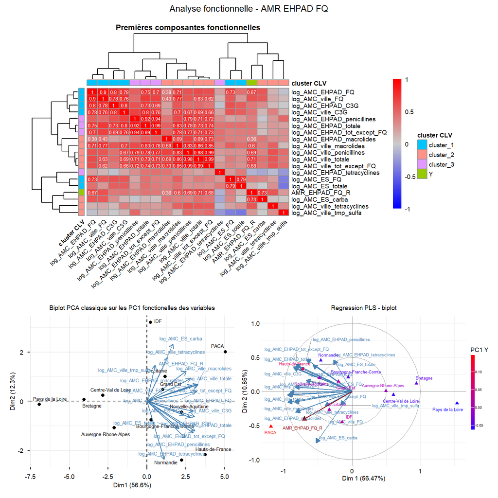

### 1.2.2 soin

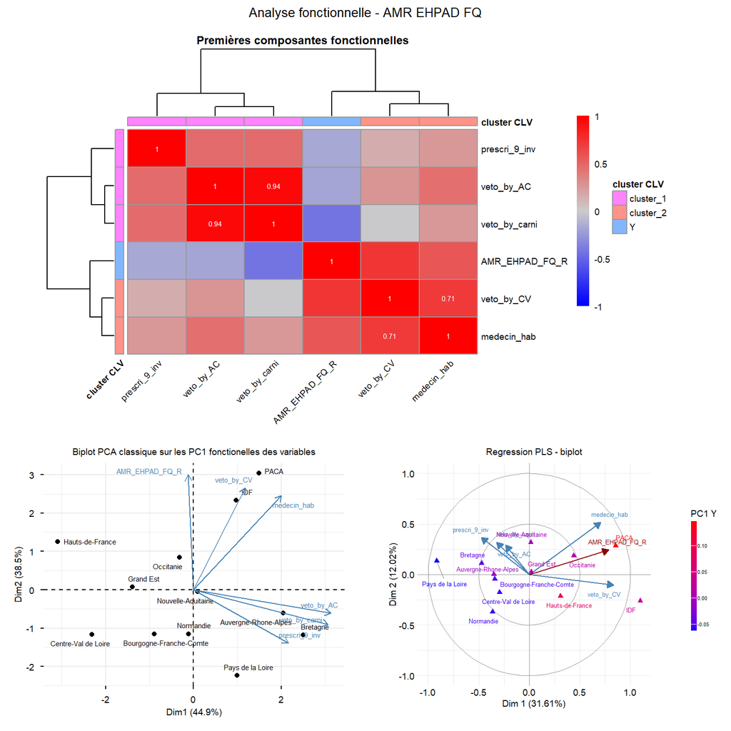

### 1.2.3 lifestyle

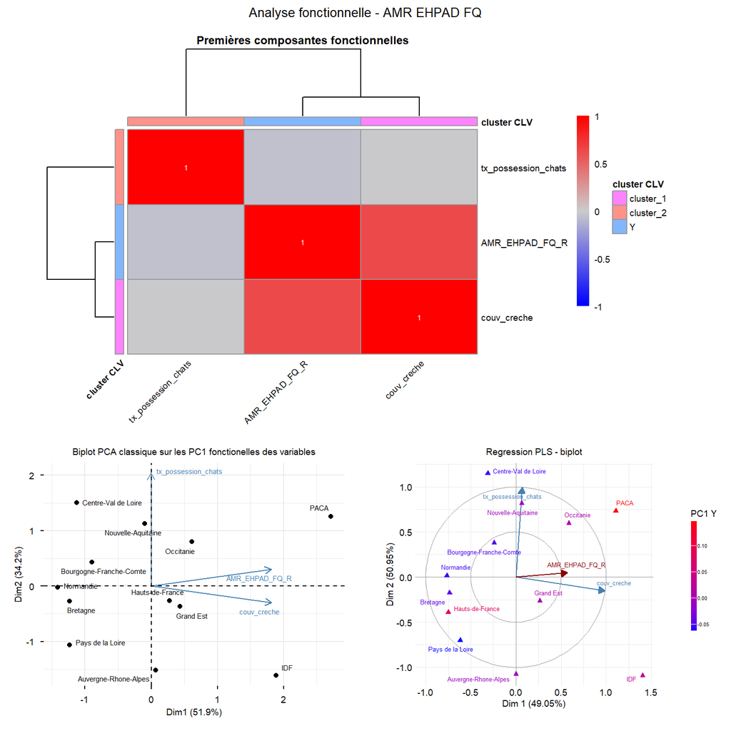

### 1.2.4 env

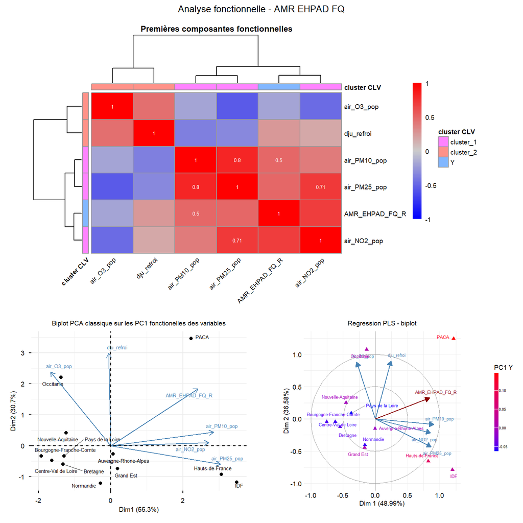

### 1.2.5 agri

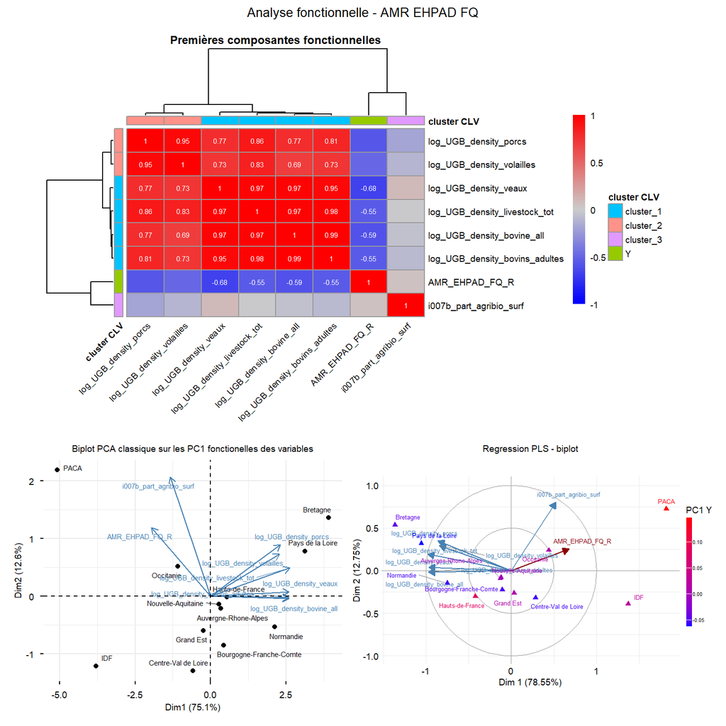

## 1.3 AMR_ES_FQ_R

```r
y <- "AMR_ES_FQ_R"
time_period <- 2019:2022
var <- selvar_AMR_ES_FQ
Nb.Base <- 3

automatisation_block(y = y, blocks = blocks, time_period = time_period, var = var,
                     Nb.Base = Nb.Base)
```

### 1.3.1 AMC

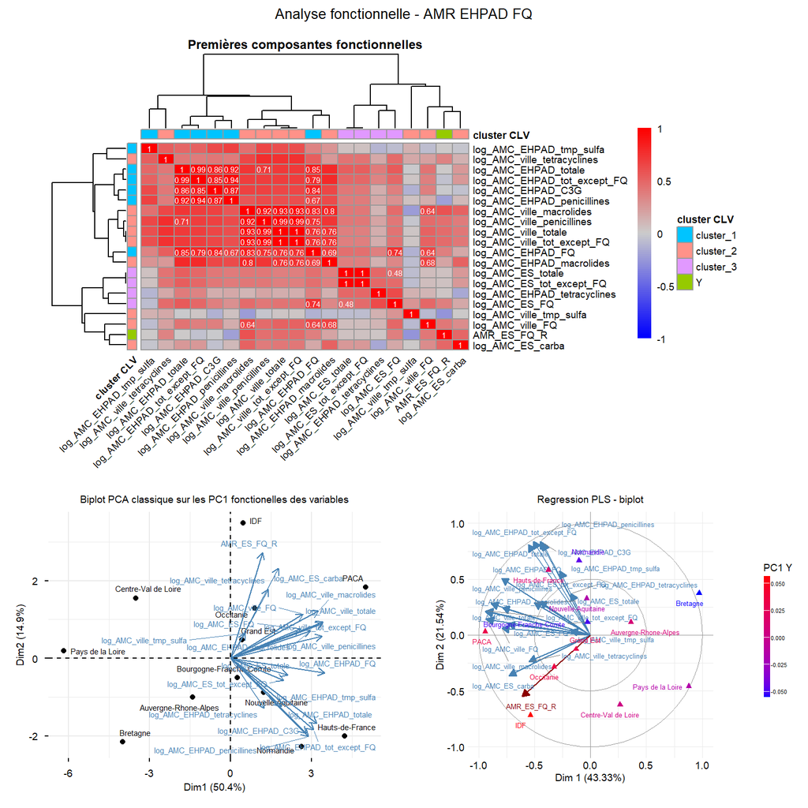

### 1.3.2 socioeco

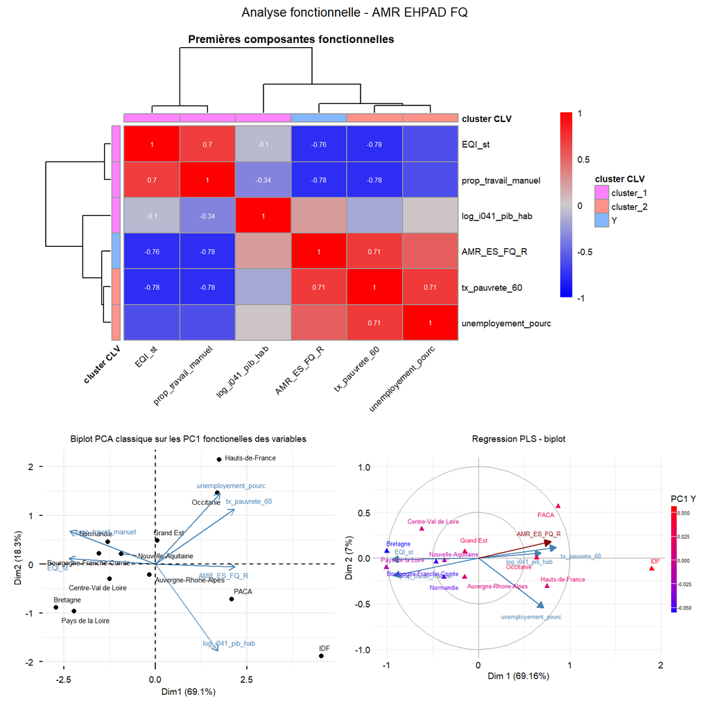

### 1.3.3 soin

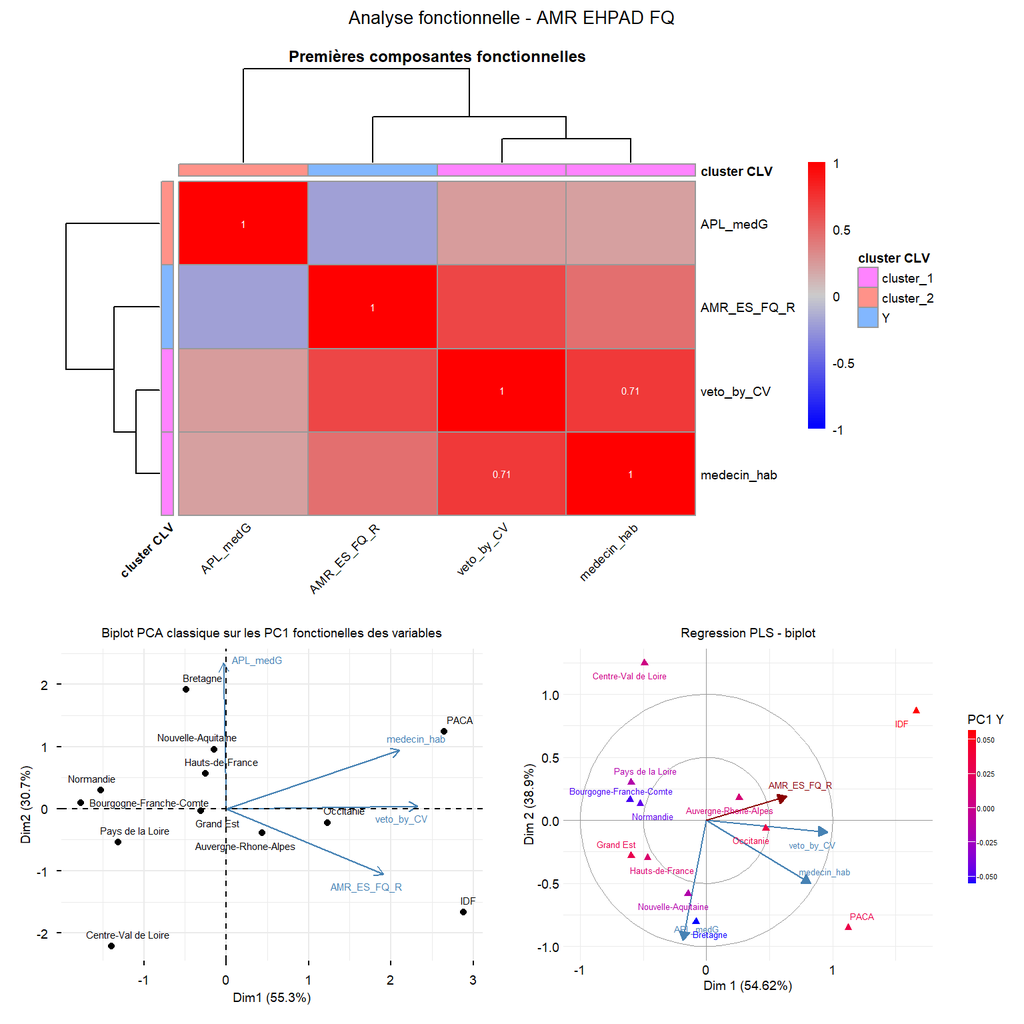

### 1.3.4 lifestyle

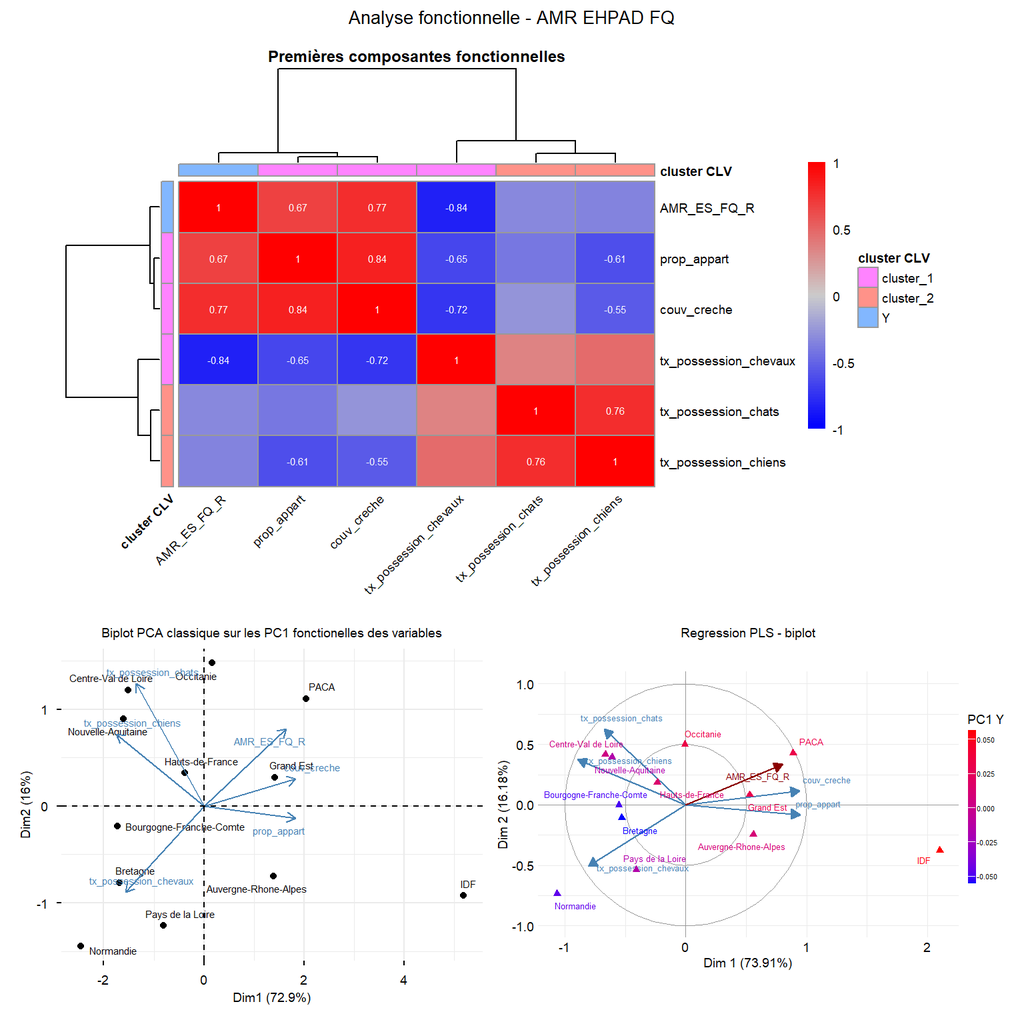

### 1.3.5 demo

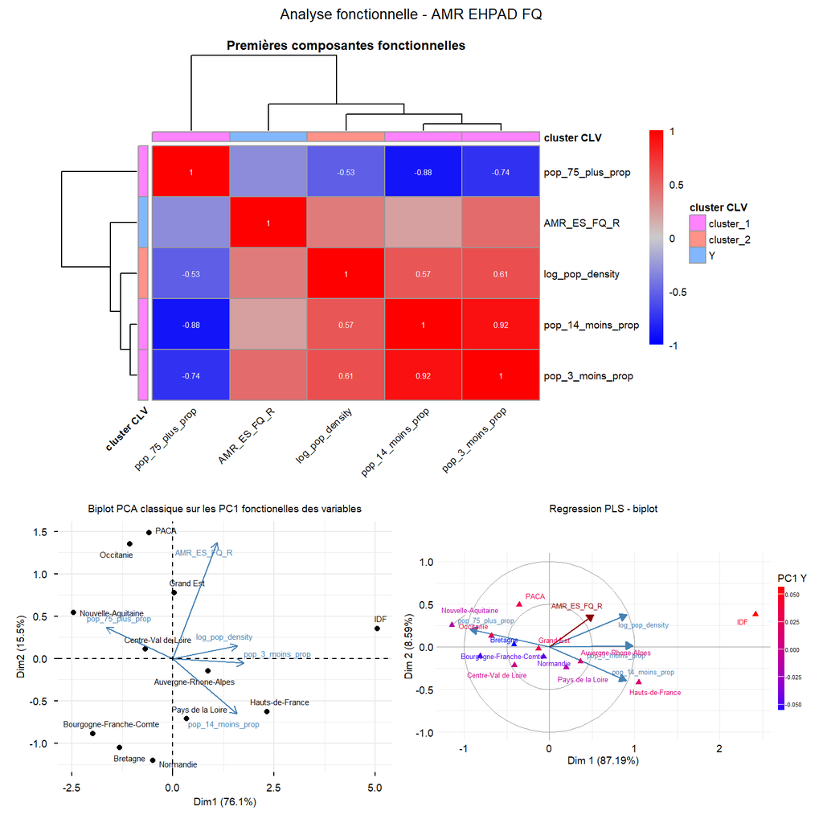

### 1.3.6 env

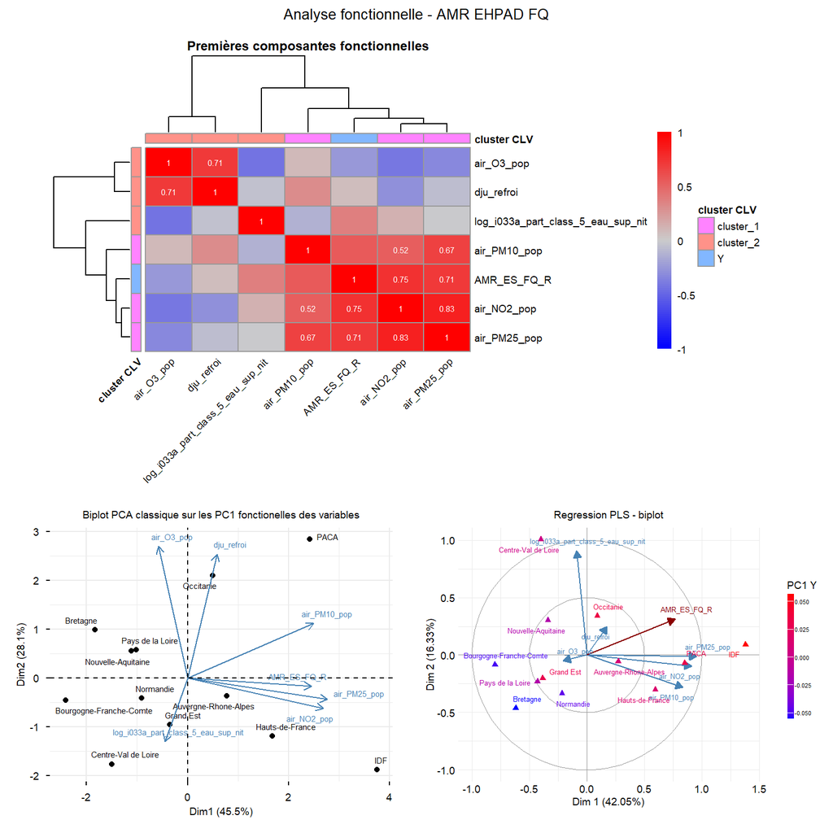

### 1.3.7 agri

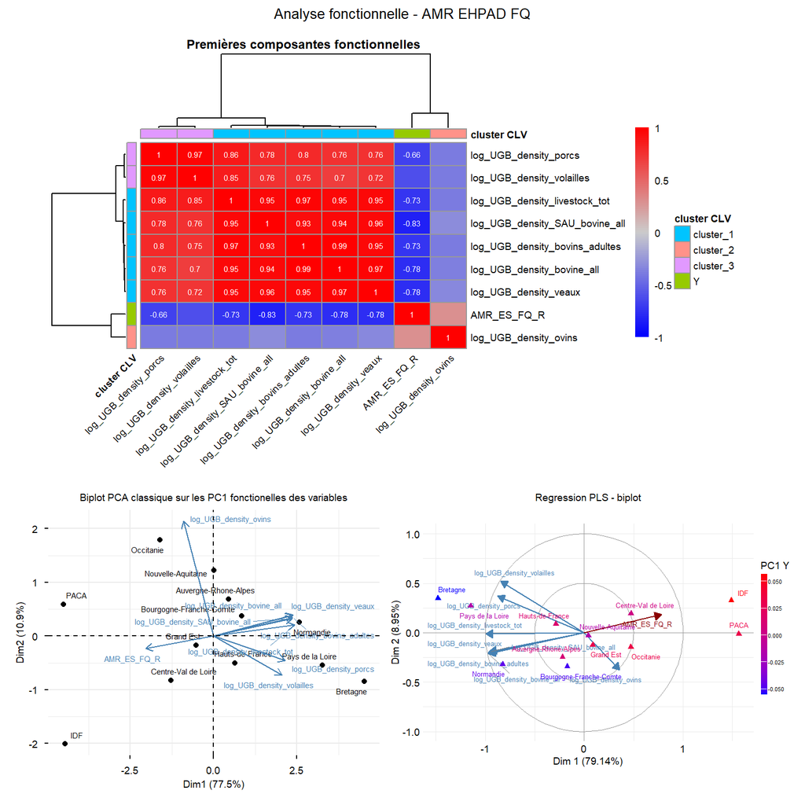

## 1.4 AMR_ville_FQ_R

```r
y <- "AMR_ville_FQ_R"
time_period <- 2020:2022
var <- selvar_AMR_ville_FQ
Nb.Base <- 3

automatisation_block(y = y, blocks = blocks, time_period = time_period, var = var,
                     Nb.Base = Nb.Base)
```

### 1.4.1 AMC

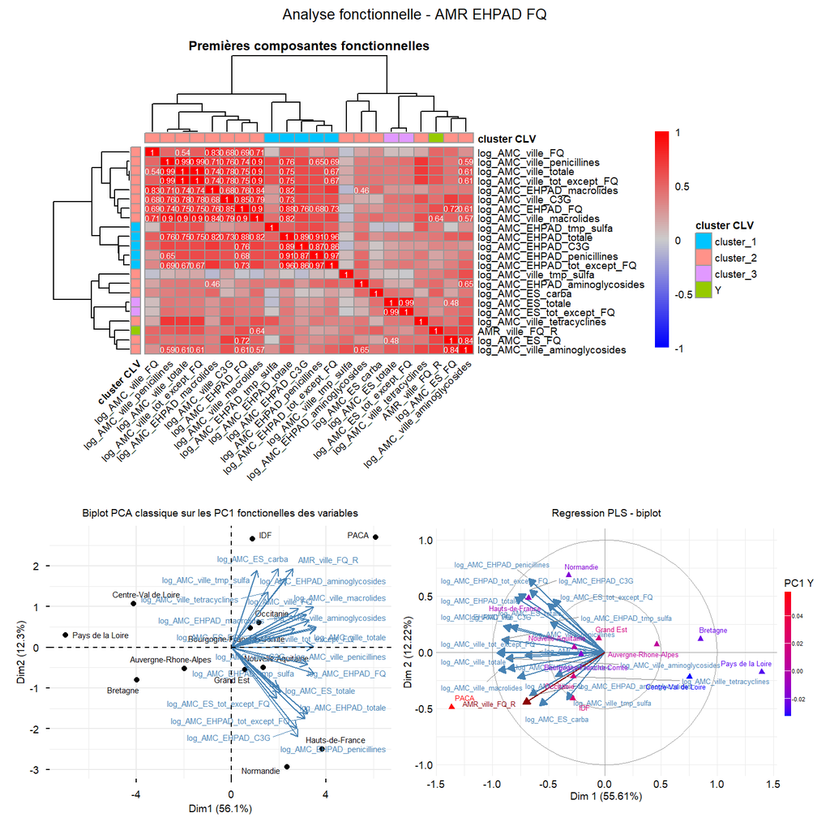

### 1.4.2 socioeco

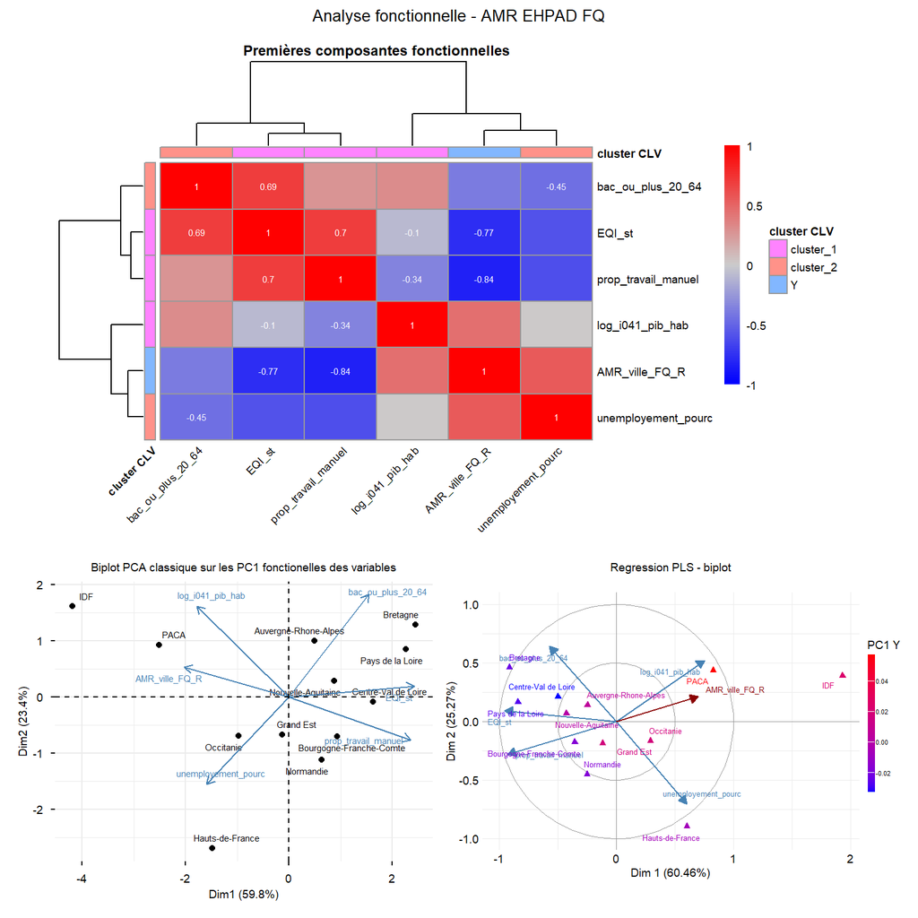

### 1.4.3 soin

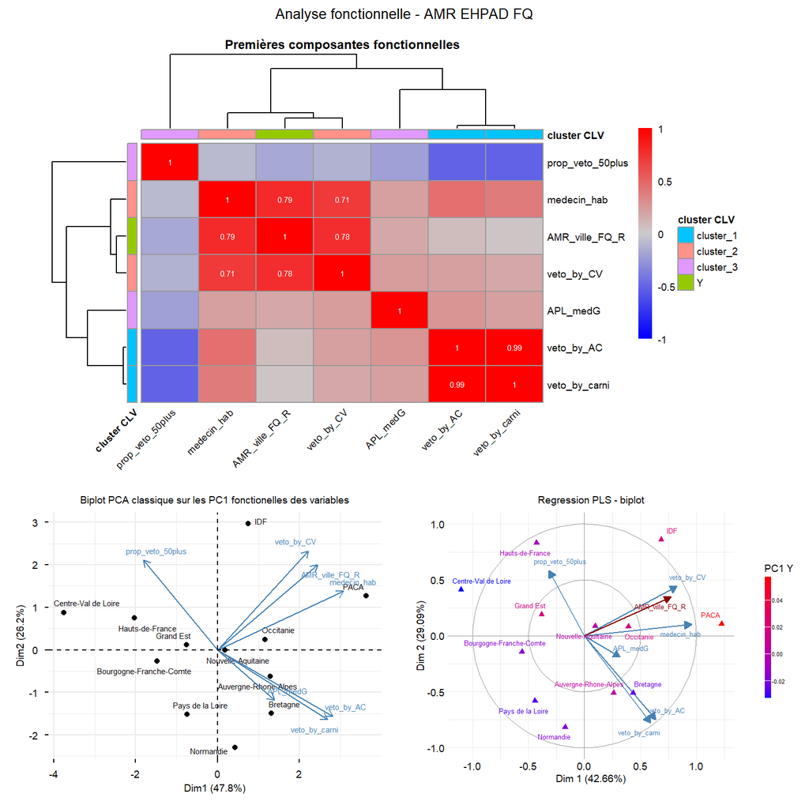

### 1.4.4 lifestyle

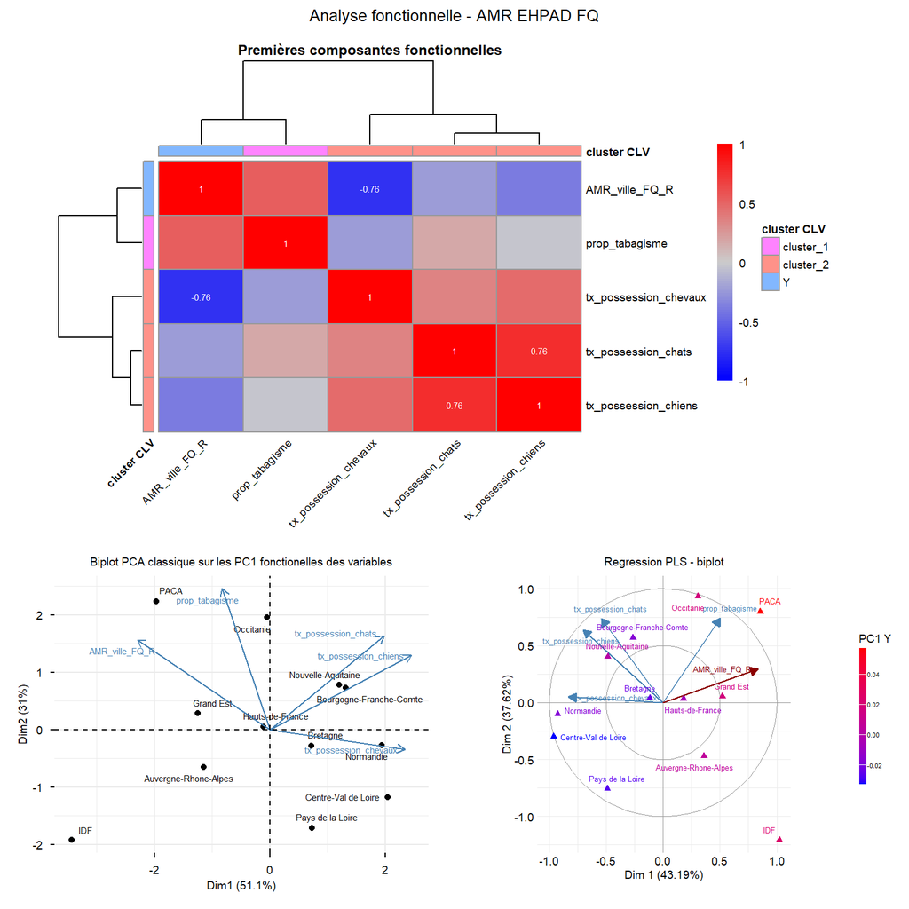

### 1.4.5 demo

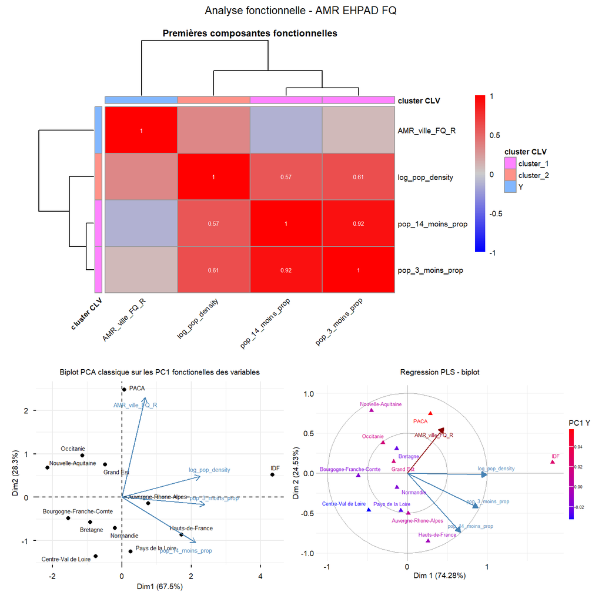

### 1.4.6 env

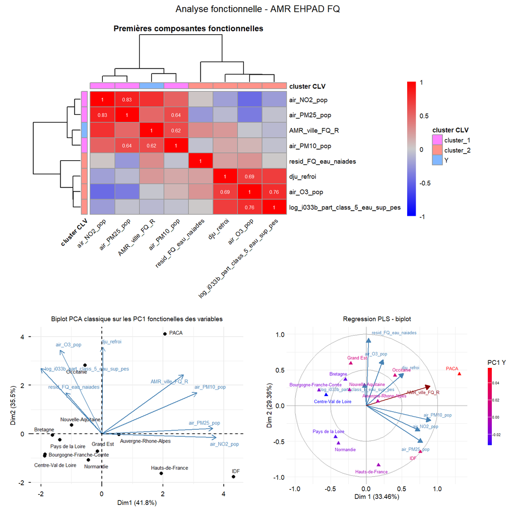

### 1.4.7 agri

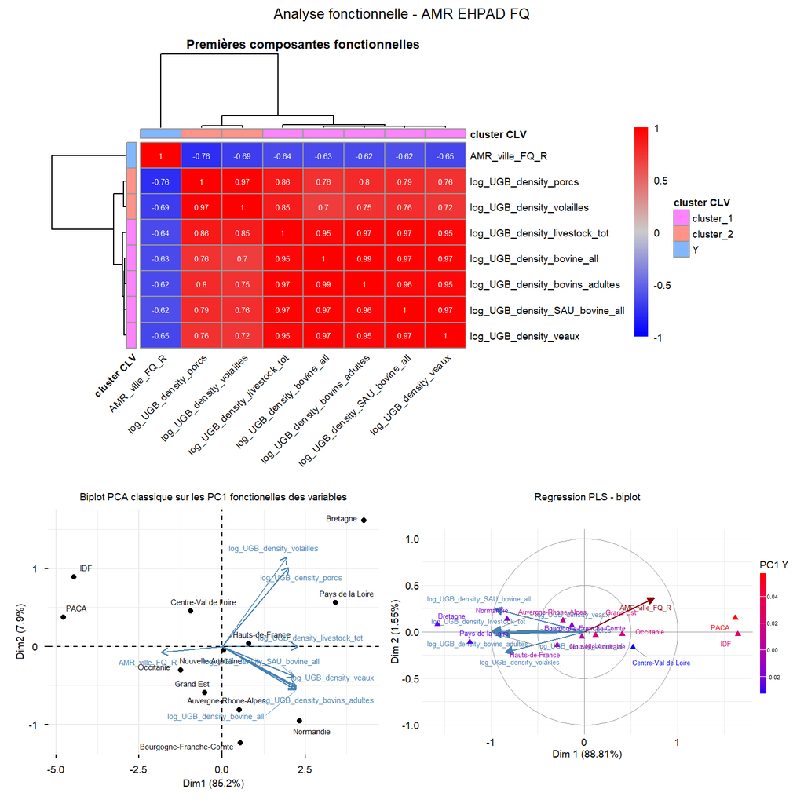

## 1.5 AMR_EHPAD_C3G_R

```r
y <- "AMR_EHPAD_C3G_R"
time_period <- 2018:2022
var <- selvar_AMR_EHPAD_C3G
Nb.Base <- 3

automatisation_block(y = y, blocks = blocks, time_period = time_period, var = var,
                     Nb.Base = Nb.Base)
```

### 1.5.1 AMC

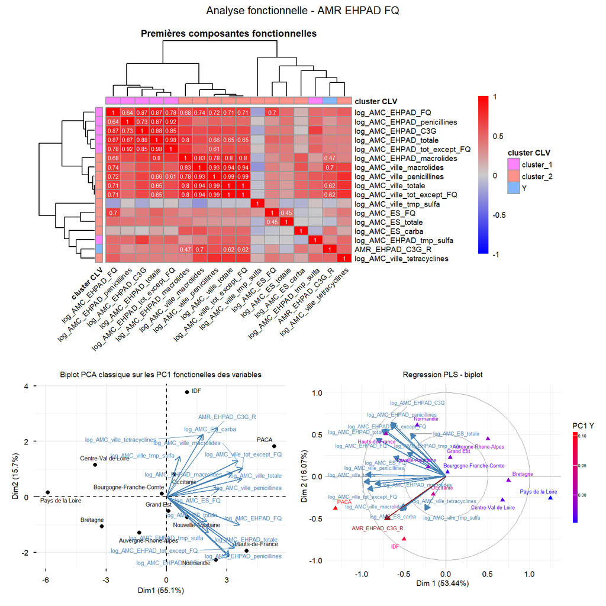

### 1.5.2 socioeco

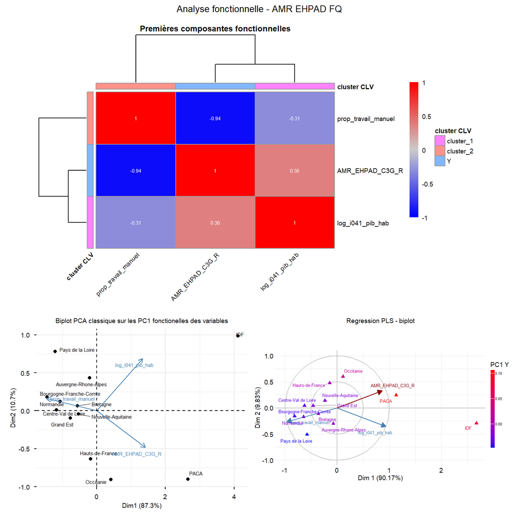

### 1.5.3 soin

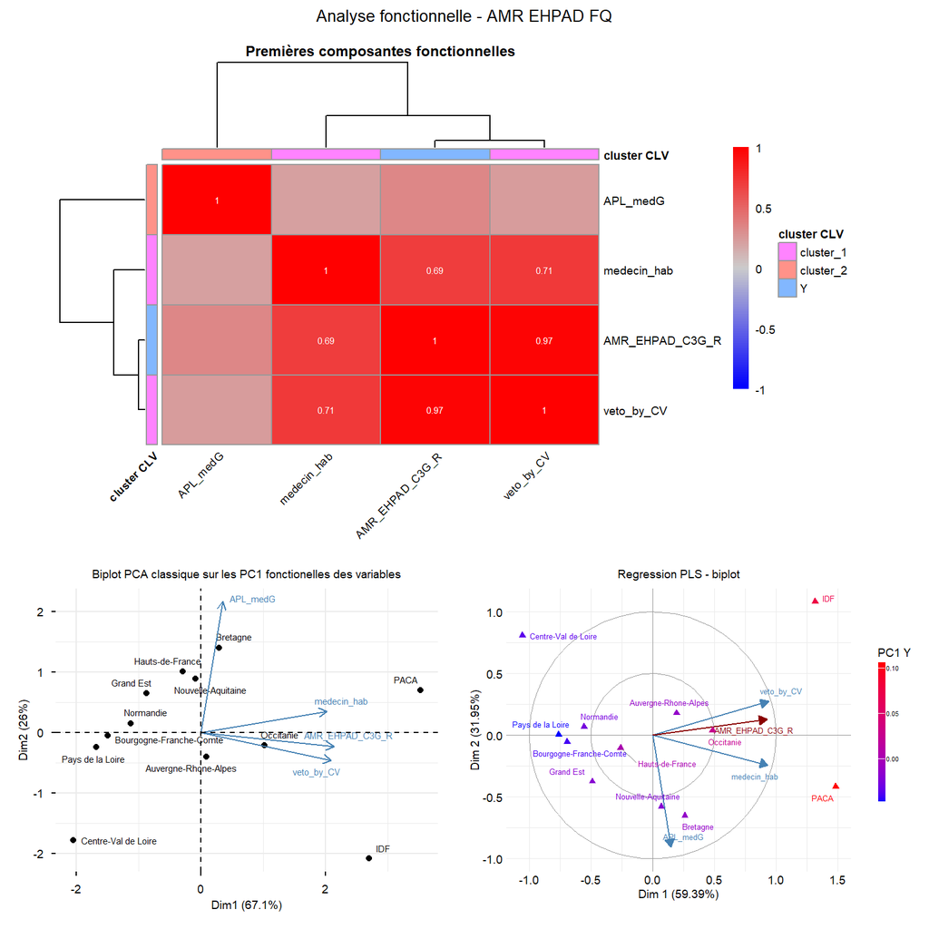

### 1.5.4 lifestyle

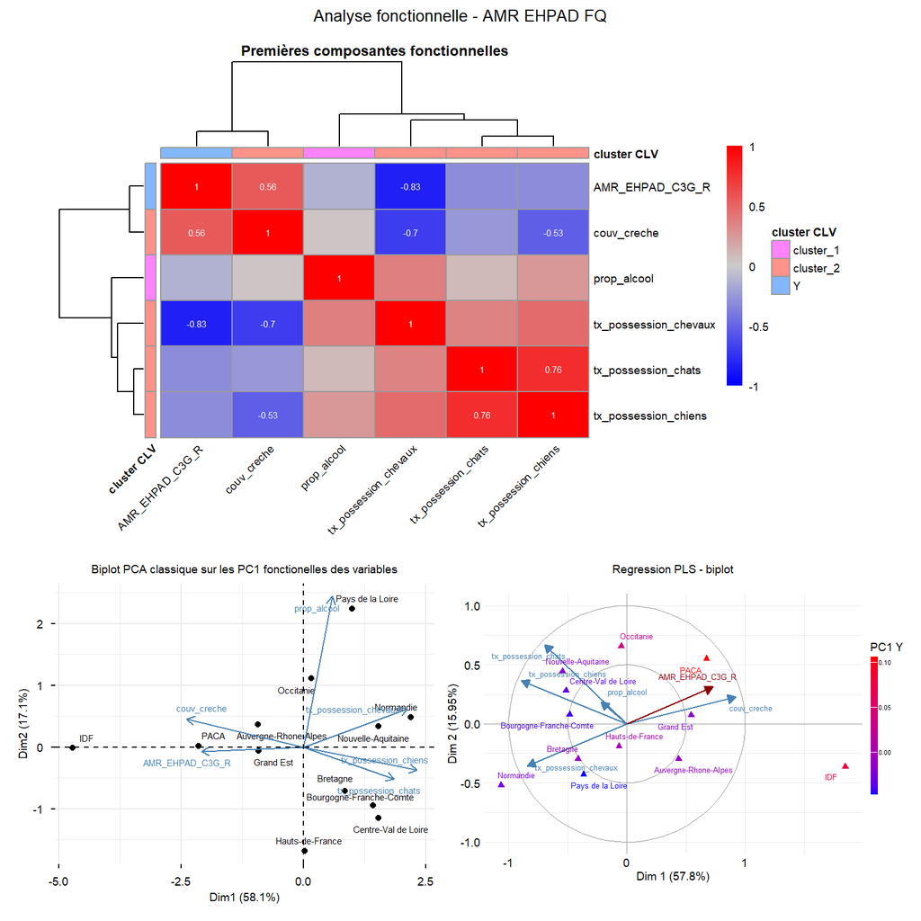

### 1.5.5 demo

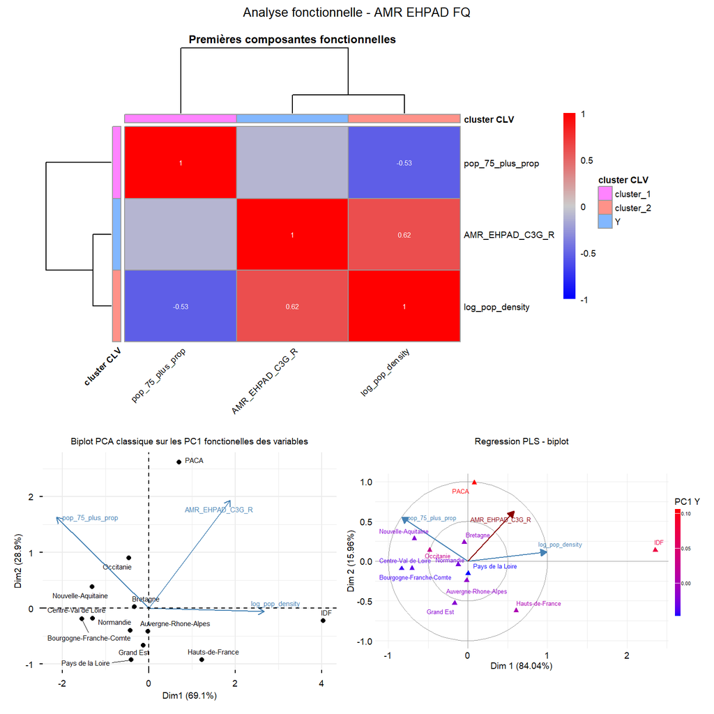

### 1.5.6 env

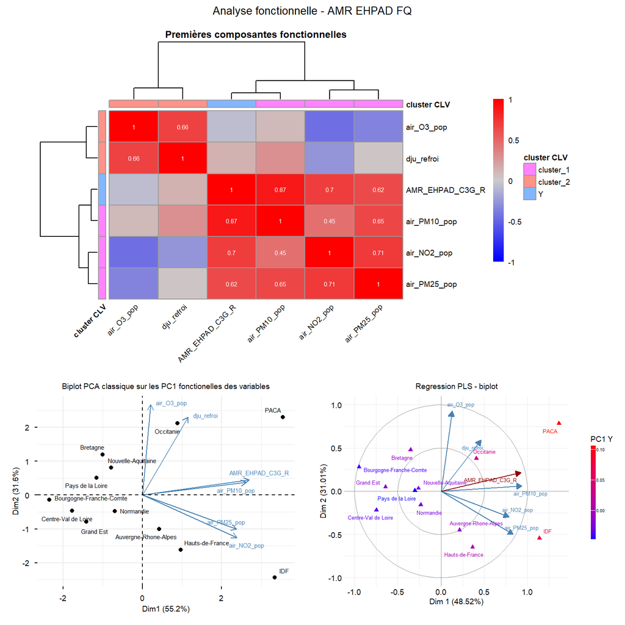

### 1.5.7 agri

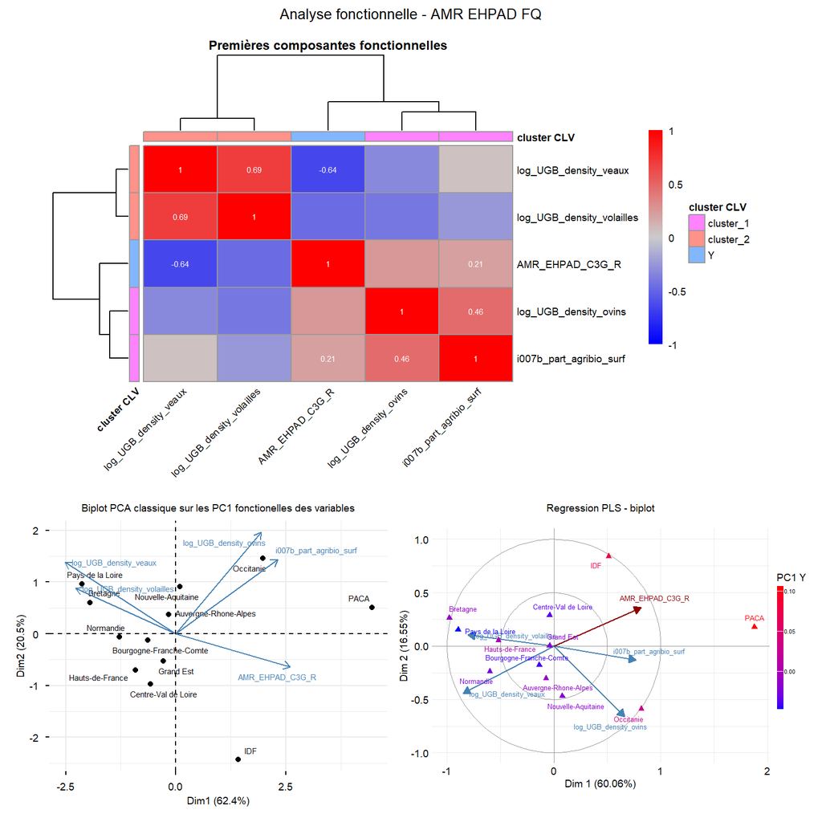

## 1.6 AMR_ES_C3G_R

```r
y <- "AMR_ES_C3G_R"
time_period <- 2019:2021
var <- selvar_AMR_ES_C3G
Nb.Base <- 3

automatisation_block(y = y, blocks = blocks, time_period = time_period, var = var, Nb.Base = Nb.Base)
```

### 1.6.1 AMC

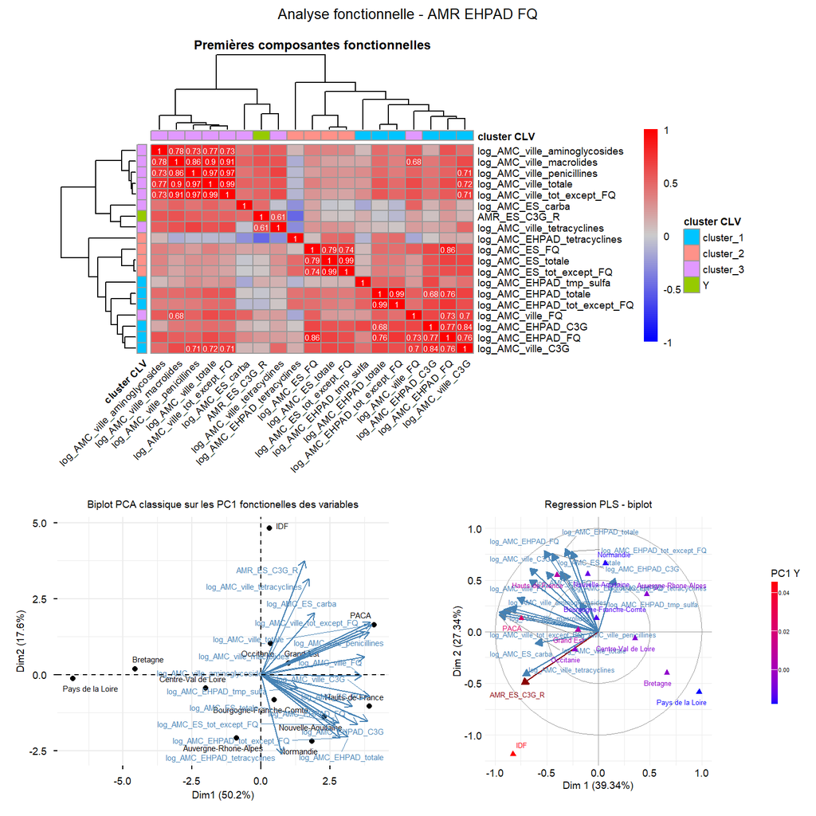

### 1.6.2 socioeco

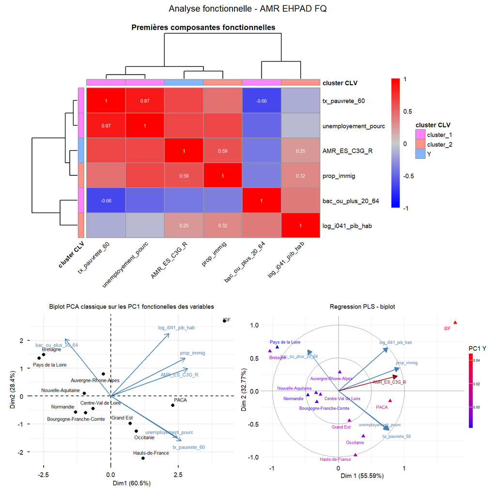

### 1.6.3 soin

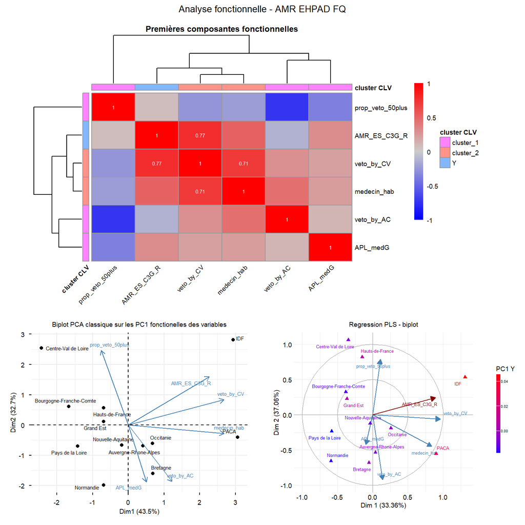

### 1.6.4 lifestyle

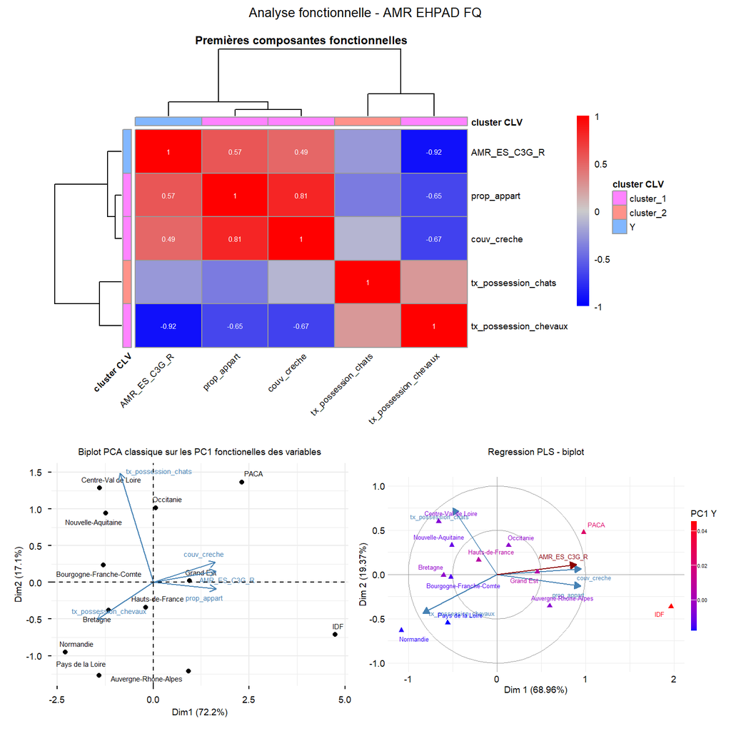

### 1.6.5 env

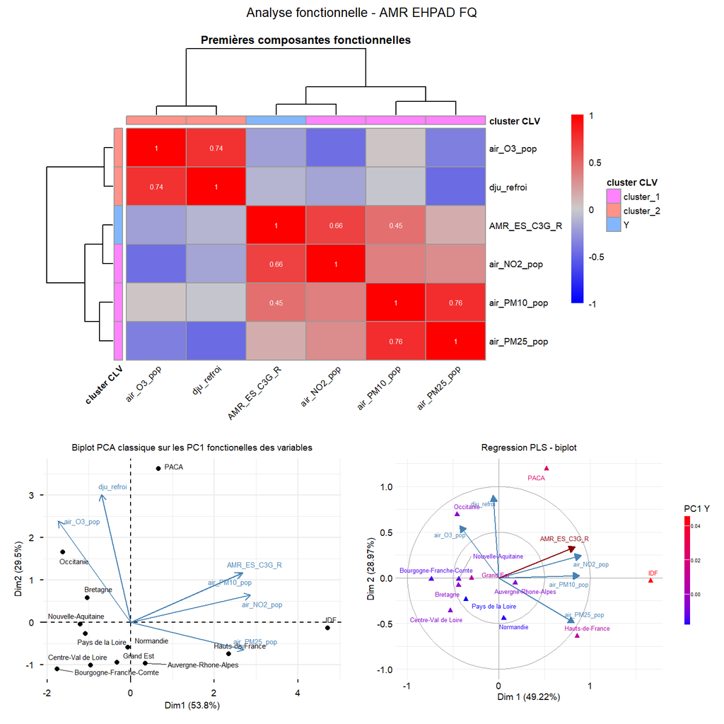

### 1.6.6 agri

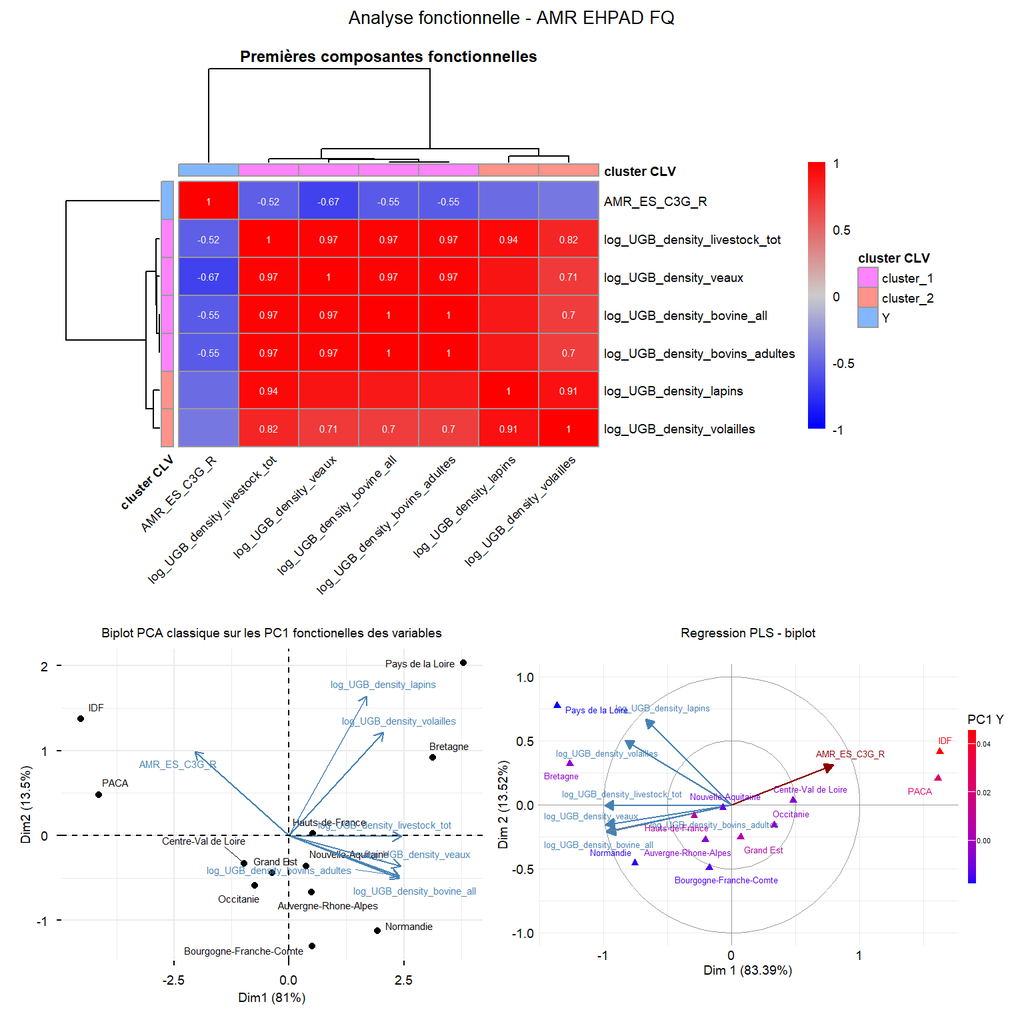